# Risk Factor Analysis

## Outcome Variable

**Outcome Variable:** y_rate_len

## Predictor Variables

**Intervention Variable:** fage

**Adjustment Set:**

- arm
- W_mage
- meducyrs
- feducyrs
- W_mhtcm
- W_mwtkg
- W_mbmi
- W_fhtcm
- single
- brthmon
- delta_W_mage
- delta_meducyrs
- delta_feducyrs
- delta_W_mhtcm
- delta_W_mwtkg
- delta_W_mbmi
- delta_W_fhtcm
- delta_single
- delta_brthmon

## Stratifying Variables

The analysis was stratified on these variable(s):

- agecat
- studyid
- country

## Data Summary

| agecat | studyid | country | fage | n_cell | n |
| --- | --- | --- | --- | --- | --- |
| 0-3 months | ki0047075b-MAL-ED | BANGLADESH | >=35 | 101 | 150 |
| 0-3 months | ki0047075b-MAL-ED | BANGLADESH | [25-30) | 14 | 150 |
| 0-3 months | ki0047075b-MAL-ED | BANGLADESH | [30-35) | 35 | 150 |
| 0-3 months | ki1119695-PROBIT | BELARUS | >=35 | 1242 | 12294 |
| 0-3 months | ki1119695-PROBIT | BELARUS | <25 | 4068 | 12294 |
| 0-3 months | ki1119695-PROBIT | BELARUS | [25-30) | 4633 | 12294 |
| 0-3 months | ki1119695-PROBIT | BELARUS | [30-35) | 2351 | 12294 |
| 0-3 months | ki0047075b-MAL-ED | BRAZIL | >=35 | 35 | 68 |
| 0-3 months | ki0047075b-MAL-ED | BRAZIL | <25 | 3 | 68 |
| 0-3 months | ki0047075b-MAL-ED | BRAZIL | [25-30) | 7 | 68 |
| 0-3 months | ki0047075b-MAL-ED | BRAZIL | [30-35) | 23 | 68 |
| 0-3 months | ki1135781-COHORTS | GUATEMALA | >=35 | 294 | 706 |
| 0-3 months | ki1135781-COHORTS | GUATEMALA | <25 | 108 | 706 |
| 0-3 months | ki1135781-COHORTS | GUATEMALA | [25-30) | 147 | 706 |
| 0-3 months | ki1135781-COHORTS | GUATEMALA | [30-35) | 157 | 706 |
| 0-3 months | ki0047075b-MAL-ED | INDIA | >=35 | 59 | 133 |
| 0-3 months | ki0047075b-MAL-ED | INDIA | <25 | 2 | 133 |
| 0-3 months | ki0047075b-MAL-ED | INDIA | [25-30) | 25 | 133 |
| 0-3 months | ki0047075b-MAL-ED | INDIA | [30-35) | 47 | 133 |
| 0-3 months | ki1000304b-SAS-CompFeed | INDIA | >=35 | 109 | 1165 |
| 0-3 months | ki1000304b-SAS-CompFeed | INDIA | <25 | 316 | 1165 |
| 0-3 months | ki1000304b-SAS-CompFeed | INDIA | [25-30) | 487 | 1165 |
| 0-3 months | ki1000304b-SAS-CompFeed | INDIA | [30-35) | 253 | 1165 |
| 0-3 months | ki0047075b-MAL-ED | NEPAL | >=35 | 32 | 63 |
| 0-3 months | ki0047075b-MAL-ED | NEPAL | [25-30) | 7 | 63 |
| 0-3 months | ki0047075b-MAL-ED | NEPAL | [30-35) | 24 | 63 |
| 0-3 months | ki0047075b-MAL-ED | PERU | >=35 | 43 | 80 |
| 0-3 months | ki0047075b-MAL-ED | PERU | <25 | 4 | 80 |
| 0-3 months | ki0047075b-MAL-ED | PERU | [25-30) | 17 | 80 |
| 0-3 months | ki0047075b-MAL-ED | PERU | [30-35) | 16 | 80 |

[output cut: 138 more lines]

The following strata were considered:

- agecat: 0-3 months, studyid: ki0047075b-MAL-ED, country: BANGLADESH
- agecat: 0-3 months, studyid: ki0047075b-MAL-ED, country: BRAZIL
- agecat: 0-3 months, studyid: ki0047075b-MAL-ED, country: INDIA
- agecat: 0-3 months, studyid: ki0047075b-MAL-ED, country: NEPAL
- agecat: 0-3 months, studyid: ki0047075b-MAL-ED, country: PERU
- agecat: 0-3 months, studyid: ki0047075b-MAL-ED, country: SOUTH AFRICA
- agecat: 0-3 months, studyid: ki0047075b-MAL-ED, country: TANZANIA, UNITED REPUBLIC OF
- agecat: 0-3 months, studyid: ki1000304b-SAS-CompFeed, country: INDIA
- agecat: 0-3 months, studyid: ki1119695-PROBIT, country: BELARUS
- agecat: 0-3 months, studyid: ki1135781-COHORTS, country: GUATEMALA
- agecat: 12-24 months, studyid: ki0047075b-MAL-ED, country: BANGLADESH
- agecat: 12-24 months, studyid: ki0047075b-MAL-ED, country: BRAZIL
- agecat: 12-24 months, studyid: ki0047075b-MAL-ED, country: INDIA
- agecat: 12-24 months, studyid: ki0047075b-MAL-ED, country: NEPAL
- agecat: 12-24 months, studyid: ki0047075b-MAL-ED, country: PERU
- agecat: 12-24 months, studyid: ki0047075b-MAL-ED, country: SOUTH AFRICA
- agecat: 12-24 months, studyid: ki0047075b-MAL-ED, country: TANZANIA, UNITED REPUBLIC OF
- agecat: 12-24 months, studyid: ki1119695-PROBIT, country: BELARUS
- agecat: 12-24 months, studyid: ki1135781-COHORTS, country: GUATEMALA
- agecat: 12-24 months, studyid: ki1135781-COHORTS, country: PHILIPPINES
- agecat: 12-24 months, studyid: ki1148112-LCNI-5, country: MALAWI
- agecat: 3-6 months, studyid: ki0047075b-MAL-ED, country: BANGLADESH
- agecat: 3-6 months, studyid: ki0047075b-MAL-ED, country: BRAZIL
- agecat: 3-6 months, studyid: ki0047075b-MAL-ED, country: INDIA
- agecat: 3-6 months, studyid: ki0047075b-MAL-ED, country: NEPAL
- agecat: 3-6 months, studyid: ki0047075b-MAL-ED, country: PERU
- agecat: 3-6 months, studyid: ki0047075b-MAL-ED, country: SOUTH AFRICA
- agecat: 3-6 months, studyid: ki0047075b-MAL-ED, country: TANZANIA, UNITED REPUBLIC OF
- agecat: 3-6 months, studyid: ki1000304b-SAS-CompFeed, country: INDIA
- agecat: 3-6 months, studyid: ki1119695-PROBIT, country: BELARUS
- agecat: 3-6 months, studyid: ki1135781-COHORTS, country: GUATEMALA
- agecat: 6-12 months, studyid: ki0047075b-MAL-ED, country: BANGLADESH
- agecat: 6-12 months, studyid: ki0047075b-MAL-ED, country: BRAZIL
- agecat: 6-12 months, studyid: ki0047075b-MAL-ED, country: INDIA
- agecat: 6-12 months, studyid: ki0047075b-MAL-ED, country: NEPAL
- agecat: 6-12 months, studyid: ki0047075b-MAL-ED, country: PERU
- agecat: 6-12 months, studyid: ki0047075b-MAL-ED, country: SOUTH AFRICA
- agecat: 6-12 months, studyid: ki0047075b-MAL-ED, country: TANZANIA, UNITED REPUBLIC OF
- agecat: 6-12 months, studyid: ki1000304b-SAS-CompFeed, country: INDIA
- agecat: 6-12 months, studyid: ki1000304b-SAS-FoodSuppl, country: INDIA
- agecat: 6-12 months, studyid: ki1119695-PROBIT, country: BELARUS
- agecat: 6-12 months, studyid: ki1135781-COHORTS, country: GUATEMALA
- agecat: 6-12 months, studyid: ki1135781-COHORTS, country: PHILIPPINES
- agecat: 6-12 months, studyid: ki1148112-LCNI-5, country: MALAWI

### Dropped Strata

Some strata were dropped due to rare outcomes:

- agecat: 0-3 months, studyid: ki0047075b-MAL-ED, country: BRAZIL
- agecat: 0-3 months, studyid: ki0047075b-MAL-ED, country: INDIA
- agecat: 0-3 months, studyid: ki0047075b-MAL-ED, country: PERU
- agecat: 0-3 months, studyid: ki0047075b-MAL-ED, country: SOUTH AFRICA
- agecat: 0-3 months, studyid: ki0047075b-MAL-ED, country: TANZANIA, UNITED REPUBLIC OF
- agecat: 3-6 months, studyid: ki0047075b-MAL-ED, country: BRAZIL
- agecat: 3-6 months, studyid: ki0047075b-MAL-ED, country: INDIA
- agecat: 3-6 months, studyid: ki0047075b-MAL-ED, country: SOUTH AFRICA
- agecat: 3-6 months, studyid: ki0047075b-MAL-ED, country: TANZANIA, UNITED REPUBLIC OF
- agecat: 6-12 months, studyid: ki0047075b-MAL-ED, country: BRAZIL
- agecat: 6-12 months, studyid: ki0047075b-MAL-ED, country: INDIA
- agecat: 6-12 months, studyid: ki0047075b-MAL-ED, country: PERU
- agecat: 6-12 months, studyid: ki0047075b-MAL-ED, country: SOUTH AFRICA
- agecat: 6-12 months, studyid: ki0047075b-MAL-ED, country: TANZANIA, UNITED REPUBLIC OF
- agecat: 12-24 months, studyid: ki0047075b-MAL-ED, country: BRAZIL
- agecat: 12-24 months, studyid: ki0047075b-MAL-ED, country: INDIA
- agecat: 12-24 months, studyid: ki0047075b-MAL-ED, country: PERU
- agecat: 12-24 months, studyid: ki0047075b-MAL-ED, country: SOUTH AFRICA
- agecat: 12-24 months, studyid: ki0047075b-MAL-ED, country: TANZANIA, UNITED REPUBLIC OF

## Methods Detail

We’re interested in the causal parameters $E[Y_a]$ for all values of $a \in \mathcal{A}$. These parameters represent the mean outcome if, possibly contrary to fact, we intervened to set all units to have $A=a$. Under the randomization and positivity assumptions, these are identified by the statistical parameters $\psi_a=E_W[E_{Y|A,W}(Y|A=a,W)]$. In addition, we’re interested in the mean of $Y$, $E[Y]$ under no intervention (the observed mean). We will estimate these parameters by using SuperLearner to fit the relevant likelihood factors – $E_{Y|A,W}(Y|A=a,W)$ and $p(A=a|W)$, and then updating our likelihood fit using a joint TMLE.

For unadjusted analyses ($W=\{\}$), initial likelihoods were estimated using Lrnr_glm to estimate the simple $E(Y|A)$ and Lrnr_mean to estimate $p(A)$. For adjusted analyses, a small library containing Lrnr_glmnet, Lrnr_xgboost, and Lrnr_mean was used.

Having estimated these parameters, we will then use the delta method to estimate relative risks and attributable risks relative to a prespecified baseline level of $A$.

[output not shown]

[output not shown]

[output not shown]

[output not shown]

[output not shown]

[output not shown]

[output not shown]

[output not shown]

# Results Detail

## Results Plots

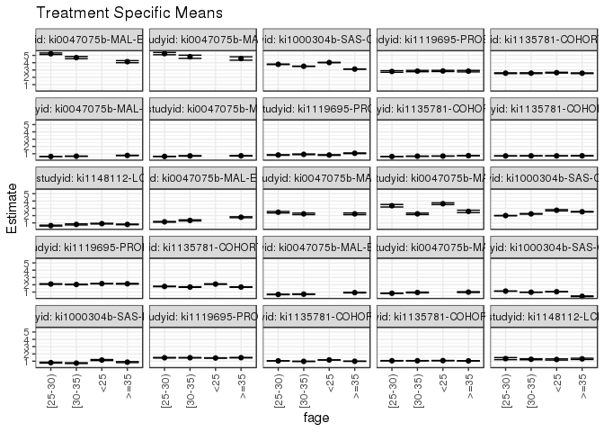

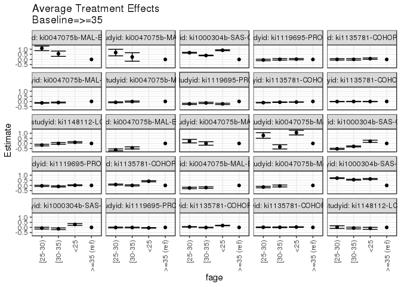

## Results Table

### Parameter: TSM

| agecat | studyid | country | intervention_level | baseline_level | estimate | ci_lower | ci_upper |
| --- | --- | --- | --- | --- | --- | --- | --- |
| 0-3 months | ki0047075b-MAL-ED | BANGLADESH | >=35 | NA | 4.1419494 | 3.9992442 | 4.2846545 |
| 0-3 months | ki0047075b-MAL-ED | BANGLADESH | [25-30) | NA | 5.2263899 | 5.1170031 | 5.3357768 |
| 0-3 months | ki0047075b-MAL-ED | BANGLADESH | [30-35) | NA | 4.7005090 | 4.5502402 | 4.8507778 |
| 0-3 months | ki0047075b-MAL-ED | NEPAL | >=35 | NA | 4.5768606 | 4.3419037 | 4.8118176 |
| 0-3 months | ki0047075b-MAL-ED | NEPAL | [25-30) | NA | 5.2470824 | 5.0935228 | 5.4006420 |
| 0-3 months | ki0047075b-MAL-ED | NEPAL | [30-35) | NA | 4.8176237 | 4.5993354 | 5.0359120 |
| 0-3 months | ki1000304b-SAS-CompFeed | INDIA | >=35 | NA | 3.1272191 | 3.1038818 | 3.1505564 |
| 0-3 months | ki1000304b-SAS-CompFeed | INDIA | <25 | NA | 4.0246813 | 3.9905863 | 4.0587763 |
| 0-3 months | ki1000304b-SAS-CompFeed | INDIA | [25-30) | NA | 3.7812703 | 3.7419535 | 3.8205871 |
| 0-3 months | ki1000304b-SAS-CompFeed | INDIA | [30-35) | NA | 3.5136182 | 3.4907889 | 3.5364475 |
| 0-3 months | ki1119695-PROBIT | BELARUS | >=35 | NA | 2.8461051 | 2.7439647 | 2.9482454 |
| 0-3 months | ki1119695-PROBIT | BELARUS | <25 | NA | 2.8707691 | 2.7899651 | 2.9515730 |
| 0-3 months | ki1119695-PROBIT | BELARUS | [25-30) | NA | 2.7974119 | 2.6904744 | 2.9043494 |
| 0-3 months | ki1119695-PROBIT | BELARUS | [30-35) | NA | 2.8558141 | 2.7655308 | 2.9460975 |
| 0-3 months | ki1135781-COHORTS | GUATEMALA | >=35 | NA | 2.5615974 | 2.5138501 | 2.6093447 |
| 0-3 months | ki1135781-COHORTS | GUATEMALA | <25 | NA | 2.6361379 | 2.5834971 | 2.6887787 |
| 0-3 months | ki1135781-COHORTS | GUATEMALA | [25-30) | NA | 2.5657108 | 2.5140493 | 2.6173723 |
| 0-3 months | ki1135781-COHORTS | GUATEMALA | [30-35) | NA | 2.5686643 | 2.5092952 | 2.6280333 |
| 3-6 months | ki0047075b-MAL-ED | BANGLADESH | >=35 | NA | 1.7799487 | 1.7141323 | 1.8457651 |
| 3-6 months | ki0047075b-MAL-ED | BANGLADESH | [25-30) | NA | 1.1512784 | 1.1004796 | 1.2020771 |
| 3-6 months | ki0047075b-MAL-ED | BANGLADESH | [30-35) | NA | 1.3419430 | 1.2697153 | 1.4141707 |
| 3-6 months | ki0047075b-MAL-ED | NEPAL | >=35 | NA | 2.2414557 | 2.1242201 | 2.3586912 |
| 3-6 months | ki0047075b-MAL-ED | NEPAL | [25-30) | NA | 2.4655540 | 2.3602731 | 2.5708349 |
| 3-6 months | ki0047075b-MAL-ED | NEPAL | [30-35) | NA | 2.2389723 | 2.1329741 | 2.3449705 |
| 3-6 months | ki0047075b-MAL-ED | PERU | >=35 | NA | 2.5763774 | 2.4143189 | 2.7384358 |
| 3-6 months | ki0047075b-MAL-ED | PERU | <25 | NA | 3.6303341 | 3.5095241 | 3.7511442 |
| 3-6 months | ki0047075b-MAL-ED | PERU | [25-30) | NA | 3.3529314 | 3.1803352 | 3.5255277 |
| 3-6 months | ki0047075b-MAL-ED | PERU | [30-35) | NA | 2.2443068 | 2.1448822 | 2.3437314 |
| 3-6 months | ki1000304b-SAS-CompFeed | INDIA | >=35 | NA | 2.5279744 | 2.4912140 | 2.5647348 |
| 3-6 months | ki1000304b-SAS-CompFeed | INDIA | <25 | NA | 2.7359982 | 2.6502133 | 2.8217831 |

[output cut: 62 more lines]

### Parameter: E(Y)

| agecat | studyid | country | intervention_level | baseline_level | estimate | ci_lower | ci_upper |
| --- | --- | --- | --- | --- | --- | --- | --- |
| 0-3 months | ki0047075b-MAL-ED | BANGLADESH | NA | NA | 3.5888777 | 3.5145520 | 3.6632034 |
| 0-3 months | ki0047075b-MAL-ED | NEPAL | NA | NA | 3.7328856 | 3.6136585 | 3.8521128 |
| 0-3 months | ki1000304b-SAS-CompFeed | INDIA | NA | NA | 3.6022342 | 3.5739584 | 3.6305100 |
| 0-3 months | ki1119695-PROBIT | BELARUS | NA | NA | 2.8363715 | 2.7230464 | 2.9496966 |
| 0-3 months | ki1135781-COHORTS | GUATEMALA | NA | NA | 2.6164613 | 2.5719057 | 2.6610169 |
| 3-6 months | ki0047075b-MAL-ED | BANGLADESH | NA | NA | 1.9151881 | 1.8526222 | 1.9777540 |
| 3-6 months | ki0047075b-MAL-ED | NEPAL | NA | NA | 1.8860484 | 1.7866718 | 1.9854250 |
| 3-6 months | ki0047075b-MAL-ED | PERU | NA | NA | 2.0391824 | 1.9190819 | 2.1592828 |
| 3-6 months | ki1000304b-SAS-CompFeed | INDIA | NA | NA | 1.9401040 | 1.8974682 | 1.9827398 |
| 3-6 months | ki1119695-PROBIT | BELARUS | NA | NA | 2.0923463 | 2.0510631 | 2.1336294 |
| 3-6 months | ki1135781-COHORTS | GUATEMALA | NA | NA | 1.7566595 | 1.7253717 | 1.7879472 |
| 6-12 months | ki0047075b-MAL-ED | BANGLADESH | NA | NA | 1.1000336 | 1.0701340 | 1.1299332 |
| 6-12 months | ki0047075b-MAL-ED | NEPAL | NA | NA | 1.1874519 | 1.1469747 | 1.2279292 |
| 6-12 months | ki1000304b-SAS-CompFeed | INDIA | NA | NA | 1.0994077 | 1.0886490 | 1.1101664 |
| 6-12 months | ki1000304b-SAS-FoodSuppl | INDIA | NA | NA | 1.0131058 | 0.9370457 | 1.0891660 |
| 6-12 months | ki1119695-PROBIT | BELARUS | NA | NA | 1.4697464 | 1.4316817 | 1.5078110 |
| 6-12 months | ki1135781-COHORTS | GUATEMALA | NA | NA | 1.0185687 | 1.0012009 | 1.0359366 |
| 6-12 months | ki1135781-COHORTS | PHILIPPINES | NA | NA | 1.0672226 | 1.0548911 | 1.0795541 |
| 6-12 months | ki1148112-LCNI-5 | MALAWI | NA | NA | 1.2956565 | 1.2080181 | 1.3832950 |
| 12-24 months | ki0047075b-MAL-ED | BANGLADESH | NA | NA | 0.8462936 | 0.8276071 | 0.8649800 |
| 12-24 months | ki0047075b-MAL-ED | NEPAL | NA | NA | 0.8519576 | 0.8288134 | 0.8751019 |
| 12-24 months | ki1119695-PROBIT | BELARUS | NA | NA | 0.8606477 | 0.8070689 | 0.9142264 |
| 12-24 months | ki1135781-COHORTS | GUATEMALA | NA | NA | 0.7806173 | 0.7696290 | 0.7916055 |
| 12-24 months | ki1135781-COHORTS | PHILIPPINES | NA | NA | 0.7056723 | 0.6982628 | 0.7130818 |
| 12-24 months | ki1148112-LCNI-5 | MALAWI | NA | NA | 0.8389480 | 0.7933802 | 0.8845158 |

### Parameter: ATE

| agecat | studyid | country | intervention_level | baseline_level | estimate | ci_lower | ci_upper |
| --- | --- | --- | --- | --- | --- | --- | --- |
| 0-3 months | ki0047075b-MAL-ED | BANGLADESH | >=35 | >=35 | 0.0000000 | 0.0000000 | 0.0000000 |
| 0-3 months | ki0047075b-MAL-ED | BANGLADESH | [25-30) | >=35 | 1.0844406 | 0.8632306 | 1.3056505 |
| 0-3 months | ki0047075b-MAL-ED | BANGLADESH | [30-35) | >=35 | 0.5585596 | 0.2986161 | 0.8185031 |
| 0-3 months | ki0047075b-MAL-ED | NEPAL | >=35 | >=35 | 0.0000000 | 0.0000000 | 0.0000000 |
| 0-3 months | ki0047075b-MAL-ED | NEPAL | [25-30) | >=35 | 0.6702218 | 0.3510939 | 0.9893496 |
| 0-3 months | ki0047075b-MAL-ED | NEPAL | [30-35) | >=35 | 0.2407631 | -0.1729839 | 0.6545100 |
| 0-3 months | ki1000304b-SAS-CompFeed | INDIA | >=35 | >=35 | 0.0000000 | 0.0000000 | 0.0000000 |
| 0-3 months | ki1000304b-SAS-CompFeed | INDIA | <25 | >=35 | 0.8974622 | 0.8556863 | 0.9392381 |
| 0-3 months | ki1000304b-SAS-CompFeed | INDIA | [25-30) | >=35 | 0.6540512 | 0.6141485 | 0.6939540 |
| 0-3 months | ki1000304b-SAS-CompFeed | INDIA | [30-35) | >=35 | 0.3863991 | 0.3569122 | 0.4158859 |
| 0-3 months | ki1119695-PROBIT | BELARUS | >=35 | >=35 | 0.0000000 | 0.0000000 | 0.0000000 |
| 0-3 months | ki1119695-PROBIT | BELARUS | <25 | >=35 | 0.0246640 | -0.0368015 | 0.0861295 |
| 0-3 months | ki1119695-PROBIT | BELARUS | [25-30) | >=35 | -0.0486931 | -0.1207709 | 0.0233847 |
| 0-3 months | ki1119695-PROBIT | BELARUS | [30-35) | >=35 | 0.0097091 | -0.0660200 | 0.0854382 |
| 0-3 months | ki1135781-COHORTS | GUATEMALA | >=35 | >=35 | 0.0000000 | 0.0000000 | 0.0000000 |
| 0-3 months | ki1135781-COHORTS | GUATEMALA | <25 | >=35 | 0.0745405 | 0.0063380 | 0.1427430 |
| 0-3 months | ki1135781-COHORTS | GUATEMALA | [25-30) | >=35 | 0.0041134 | -0.0634389 | 0.0716657 |
| 0-3 months | ki1135781-COHORTS | GUATEMALA | [30-35) | >=35 | 0.0070669 | -0.0660964 | 0.0802301 |
| 3-6 months | ki0047075b-MAL-ED | BANGLADESH | >=35 | >=35 | 0.0000000 | 0.0000000 | 0.0000000 |
| 3-6 months | ki0047075b-MAL-ED | BANGLADESH | [25-30) | >=35 | -0.6286703 | -0.7230604 | -0.5342802 |
| 3-6 months | ki0047075b-MAL-ED | BANGLADESH | [30-35) | >=35 | -0.4380058 | -0.5439686 | -0.3320430 |
| 3-6 months | ki0047075b-MAL-ED | NEPAL | >=35 | >=35 | 0.0000000 | 0.0000000 | 0.0000000 |
| 3-6 months | ki0047075b-MAL-ED | NEPAL | [25-30) | >=35 | 0.2240983 | 0.0555735 | 0.3926231 |
| 3-6 months | ki0047075b-MAL-ED | NEPAL | [30-35) | >=35 | -0.0024834 | -0.1726469 | 0.1676801 |
| 3-6 months | ki0047075b-MAL-ED | PERU | >=35 | >=35 | 0.0000000 | 0.0000000 | 0.0000000 |
| 3-6 months | ki0047075b-MAL-ED | PERU | <25 | >=35 | 1.0539568 | 0.8293237 | 1.2785899 |
| 3-6 months | ki0047075b-MAL-ED | PERU | [25-30) | >=35 | 0.7765541 | 0.5001243 | 1.0529838 |
| 3-6 months | ki0047075b-MAL-ED | PERU | [30-35) | >=35 | -0.3320705 | -0.5432646 | -0.1208765 |
| 3-6 months | ki1000304b-SAS-CompFeed | INDIA | >=35 | >=35 | 0.0000000 | 0.0000000 | 0.0000000 |
| 3-6 months | ki1000304b-SAS-CompFeed | INDIA | <25 | >=35 | 0.2080238 | 0.0988896 | 0.3171580 |

[output cut: 62 more lines]